# 2. Regression and model validation, analysis

*Describe the work you have done this week and summarize your learning.*

*- Describe your work and results clearly.* *- Assume the reader has an introductory course level understanding of writing and reading R code as well as statistical methods* *- Assume the reader has no previous knowledge of your data or the more advanced methods you are using*

## Summary of the data

```r
data1 <- read.table("data/learning2014.txt" , sep = ",",
header = TRUE)
```

This weeks tasks is to present the material we are going to be working with and run a multiple regression model. While presenting the material, we will also need to provide visuals of the multiple regression models and the distribution of each variable. We have to explain the outputs of visuals and summaries.

I begin to visualize the content of the whole material, so I summarise the content of the variable data1, and then I will proceed to visualize data1’s different dimensions:

```r
summary(data1)
```

```
##  gender       age           attitude          deep            stra
##  F:110   Min.   :17.00   Min.   :1.400   Min.   :1.583   Min.   :1.250
##  M: 56   1st Qu.:21.00   1st Qu.:2.600   1st Qu.:3.333   1st Qu.:2.625
##          Median :22.00   Median :3.200   Median :3.667   Median :3.188
##          Mean   :25.51   Mean   :3.143   Mean   :3.680   Mean   :3.121
##          3rd Qu.:27.00   3rd Qu.:3.700   3rd Qu.:4.083   3rd Qu.:3.625
##          Max.   :55.00   Max.   :5.000   Max.   :4.917   Max.   :5.000
##       surf           points
##  Min.   :1.583   Min.   : 7.00
##  1st Qu.:2.417   1st Qu.:19.00
##  Median :2.833   Median :23.00
##  Mean   :2.787   Mean   :22.72
##  3rd Qu.:3.167   3rd Qu.:27.75
##  Max.   :4.333   Max.   :33.00
```

```r
dim(data1)
```

```
## [1] 166   7
```

As we can se, the data consists of 7 different variables gender, age, attitude, deep, stra, surf and points, and it has a total of 166 observations. The summary function gives 6 different basic key figures; minimum, 1st quartile, median, mean, 3rd quartile and maximum values.

The minimum and maximum values gives the variables smallest and largest values.

The 1st and the 3rd quartile explain how many people are in the first 25% of the content (1st), and how many are included in the first 75%. These functions are usefull, because you will know where the middle 50% of the content has placed themselves.

Median is the value that is in the middle, if you gather the data in the order that the smallest values comes first, and the highest values comes last.

The mean value is the all the values of a variable divided in the numbers of observatios there is int the variable.

Now I want to present the structure of the data, which includes what type of variables (numerical, logical, character).

```r
str(data1)
```

```
## 'data.frame':    166 obs. of  7 variables:
##  $ gender  : Factor w/ 2 levels "F","M": 1 2 1 2 2 1 2 1 2 1 ...
##  $ age     : int  53 55 49 53 49 38 50 37 37 42 ...
##  $ attitude: num  3.7 3.1 2.5 3.5 3.7 3.8 3.5 2.9 3.8 2.1 ...
##  $ deep    : num  3.58 2.92 3.5 3.5 3.67 ...
##  $ stra    : num  3.38 2.75 3.62 3.12 3.62 ...
##  $ surf    : num  2.58 3.17 2.25 2.25 2.83 ...
##  $ points  : int  25 12 24 10 22 21 21 31 24 26 ...
```

We can see how the different variables are coded either with ‘num’,‘int’ or ‘Factor’. This provides information on how the variables has been measured.

The code ‘int’ means intervall, and these variables can range between a surtain amount of i.e. points. Intervall data has the same range between every outcome, i.e. the variable age is easy to measure and compare, because for every year, there is the same distance.

## Visualizing variable distributions

### -gender variable

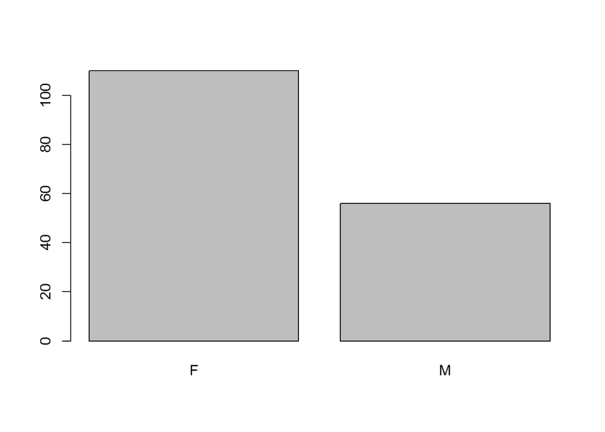

```r
plot(data1$gender)
```

As we can se, a majority of the respondents are women, and from the summary we can find that there are 110 women and 56 men.

### -age variable

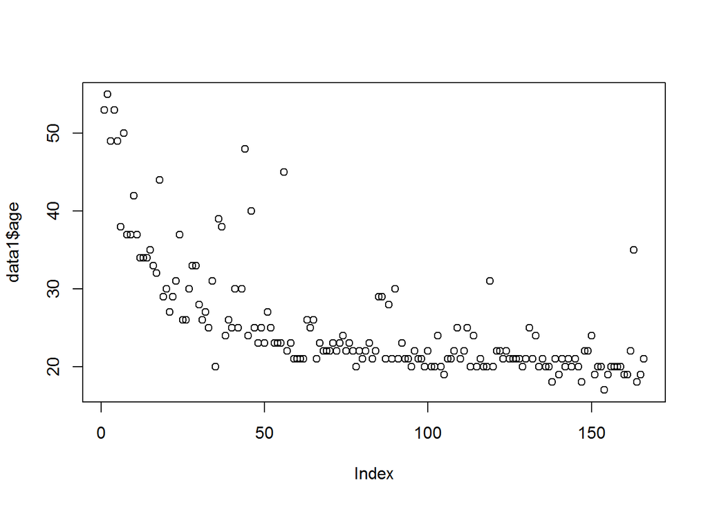

```r
plot(data1$age)
```

Here we can see that most of the respondents are in their 20s (between 21 and 27) and the mean age is arounf 25.5 years. 75% av the respodents are 27 or below, so we have quite young respondents.

### -Attitude variable

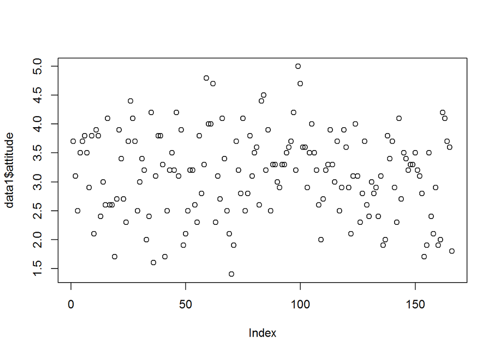

```r
plot(data1$attitude)
```

Here we can se how the the attitude variable is very scattered, and has a median and mean around 3. The variable ranges from 1 to 5. This could indicate that people have very different attitudes regarding this surtain topic.

### -Deep variable

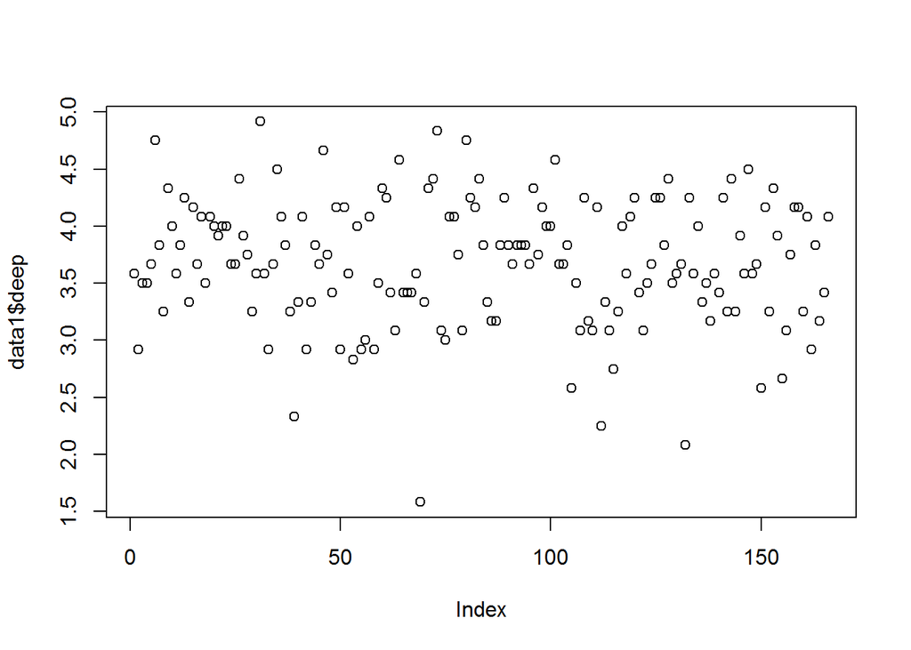

```r
plot(data1$deep)
```

Here we can se that most of the respondents has a value between 3 and 4 (1st and 3d quartile) on the deep variable.

### - Stra variable

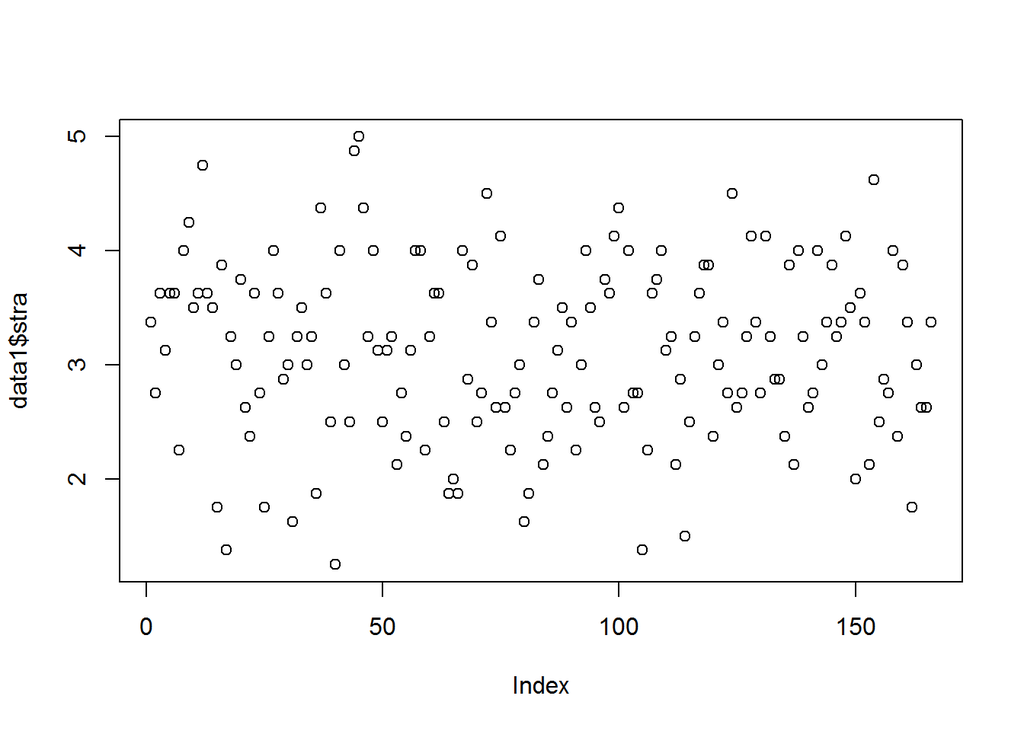

```r
plot(data1$stra)
```

The distribution in variable stra is also quite scattered, but the middle 50% is between 2,625 and 3,625 (1st and 3rd quartile).

### - Surf variable

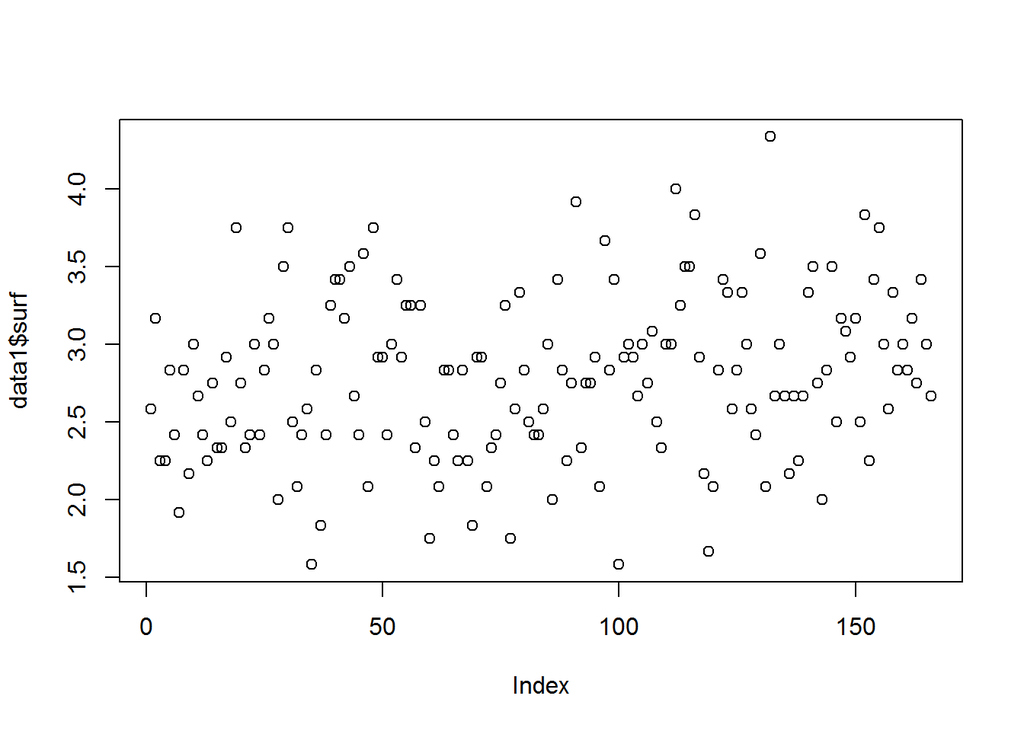

```r
plot(data1$surf)
```

In the surf variable we can see that the distribution is gathered between 2,4 and 3,4. But over all this variable is also quite scattered.

### -points variable

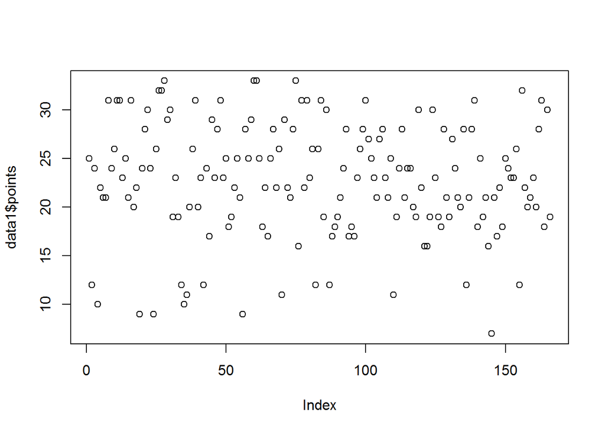

```r
plot(data1$points)
```

Here we can se that the points range between 7 and 33 points, and most of the respondents has over 20 points.

### All variables compared with each other

Now when I have all the summaries of the variables, I want to present a table where all the variables are compared with each other. The color distribution separates between women and men.

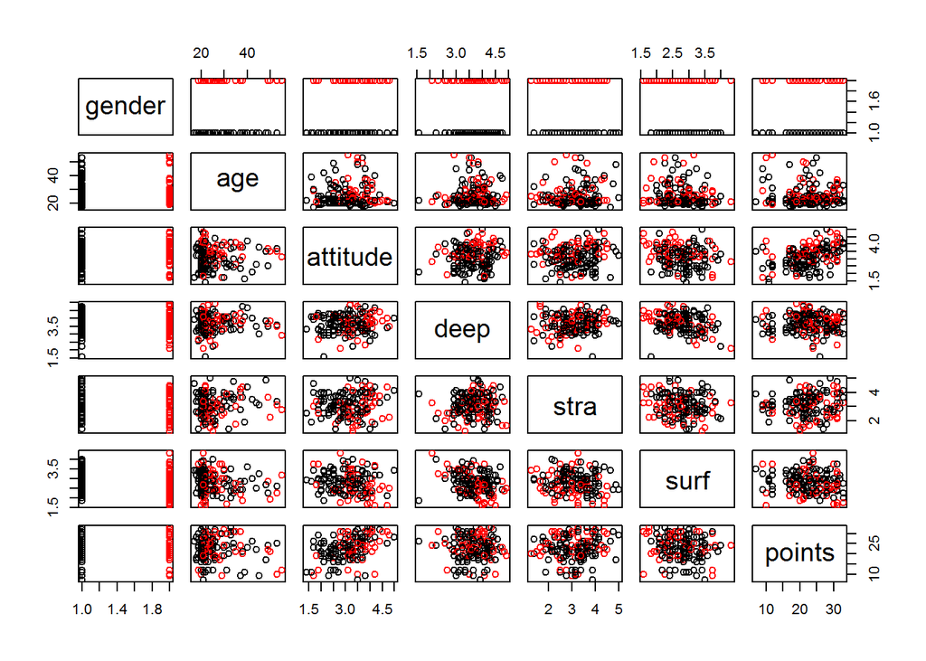

```r
pairs(data1, col = data1$gender)
```

From this table you can see if any of the different variabes correlate with each other to some extent. This is a good table to visualize the whole materials distribution in one picture.

### -Task 3, multiple regression

I created a function consisting of a multiple regression. The target variable is points, and the 3 explanatory variables are attitude, stra and deep.

```r
model1 <- lm(data1$points ~ data1$attitude + data1$stra + data1$deep, data = data1)
```

And now a summary of the multiple regression model:

```r
summary(model1)
```

```
##
## Call:
## lm(formula = data1$points ~ data1$attitude + data1$stra + data1$deep,
##     data = data1)
##
## Residuals:
##      Min       1Q   Median       3Q      Max
## -17.5239  -3.4276   0.5474   3.8220  11.5112
##
## Coefficients:
##                Estimate Std. Error t value Pr(>|t|)
## (Intercept)     11.3915     3.4077   3.343  0.00103 **
## data1$attitude   3.5254     0.5683   6.203 4.44e-09 ***
## data1$stra       0.9621     0.5367   1.793  0.07489 .
## data1$deep      -0.7492     0.7507  -0.998  0.31974
## ---
## Signif. codes:  0 '***' 0.001 '**' 0.01 '*' 0.05 '.' 0.1 ' ' 1
##
## Residual standard error: 5.289 on 162 degrees of freedom
## Multiple R-squared:  0.2097, Adjusted R-squared:  0.195
## F-statistic: 14.33 on 3 and 162 DF,  p-value: 2.521e-08
```

Here we can see the 3 different explanatory variables, and also the target variable under the title ‘Coefficients’. The Intercept, is the value in the multiple regression where it crosses the y-axis, so it means that when all the explanatory variables (x) are 0, the regression line starts at 11.3915 on the y-axis.

The first explanatory variable attitude’s estimate is 3,5254, which means that every one point higher on the explanatory variable attitude, the target variable points will increase on average by 3,5254 points, if the other explanatory variables are constant. The second explanatory variable stra’s estimate is 0,9621, which means that every point higher on this explanatory variable, the target variable will increase on average by 0,9621 if the other explanatory variables are constant. The third explanatory variable deep’s estimate is -0,7493, which means that every one point higher on the explanatory variable deep, the target variable will on average decrease by 0,7492 points, if the other explanatory variables are constant.

But before we can accept this multiple regression model, we have to look at the Pr(>|t|). The Pr(>|t|) explain if the specific explanatory variable is statistically significant or not. Usually the boarder for being statistically significant is either 0,05 or 0,01 depending on what has been chosen. We don’t need to look at the intercepts Pr(>|t|), but we need to look at the explanatory variables Pr(>|t|). The explanatory variable attitude has a Pr(>|t|) that is smaller than 0,000, which concludes that it is statistically significant. The next explanatory variable stra has a Pr(>|t|) of 0,074, which means it is statistically insignificant, that means this variable isn’t for surtain a good model for this multiple regression. The last explanatory variable deep has aPr(>|t|) of 0,319, which means it is statistically very insignificant. Having 2 insignificant values, I will skip the value that was less significant (deep) and run the multiple regression again, but now with only 2 explanatory variables.

### -Multiple regression vol 2

```r
model2 <-(lm(data1$points ~ data1$attitude + data1$stra))
```

summary of the new model

```r
summary(model2)
```

```
##
## Call:
## lm(formula = data1$points ~ data1$attitude + data1$stra)
##
## Residuals:
##      Min       1Q   Median       3Q      Max
## -17.6436  -3.3113   0.5575   3.7928  10.9295
##
## Coefficients:
##                Estimate Std. Error t value Pr(>|t|)
## (Intercept)      8.9729     2.3959   3.745  0.00025 ***
## data1$attitude   3.4658     0.5652   6.132 6.31e-09 ***
## data1$stra       0.9137     0.5345   1.709  0.08927 .
## ---
## Signif. codes:  0 '***' 0.001 '**' 0.01 '*' 0.05 '.' 0.1 ' ' 1
##
## Residual standard error: 5.289 on 163 degrees of freedom
## Multiple R-squared:  0.2048, Adjusted R-squared:  0.1951
## F-statistic: 20.99 on 2 and 163 DF,  p-value: 7.734e-09
```

### -Multiple R Squared

The multiple R squared is how much the explanatory variables explain about the variation in the target variable.

In my secound multiple regression model the multiple R squared value is 0,2048. This value explains that 20,48% of the variation in the target value points, is explained by the variation in the explanatory variables attitude and stra.

If the explanatory variable can explain over 20% of the variation in the target variable, it is quite a good regression model.

But in my case, the secound explanatory variable was insignificant, so I am not surtain if this model is so good after all.

### -Task 5

I will produce diagnstic plots: Residuals vs Fitted values, Normal QQ-plot and Residuals vs Leverage. I will produce these plots with the multiple regression model with only 2 explanatory variables (attitude and stra).

### Residuals vs Fitted

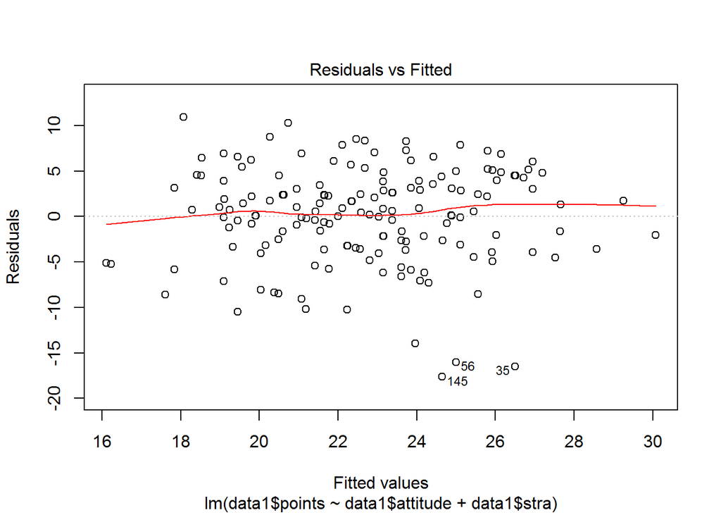

```r
plot(model2, which = c(1))
```

This table has the residual on the y-axis, and all the fitted values on the x-axis. The red stripe defines the fitted values residual and how well the multiple regressions fits this residual. We can se how most of the values are gathered between 18 to 27, and that they differ from the residuals between -10 to 10.

### Normal QQ-plot

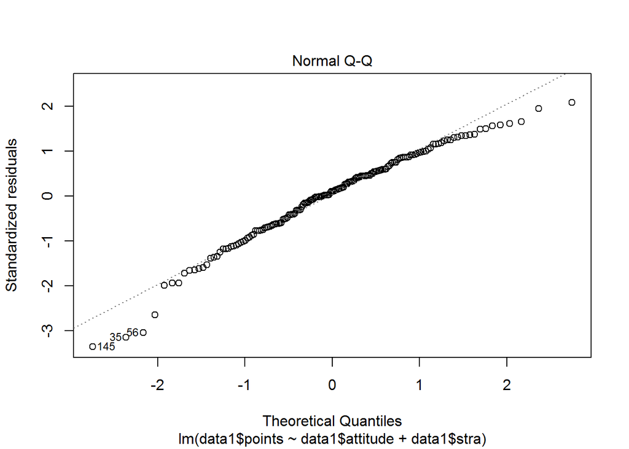

```r
plot(model2, which = c(2))
```

Here is the same thing, the better the theoretical quantiles fit on the line, the better the multiple regression is. Because the closer you are to the regression line, the better is your regression, because the closer to the residuals you are, the less error there is in you model.

### Residuals vs Leverage

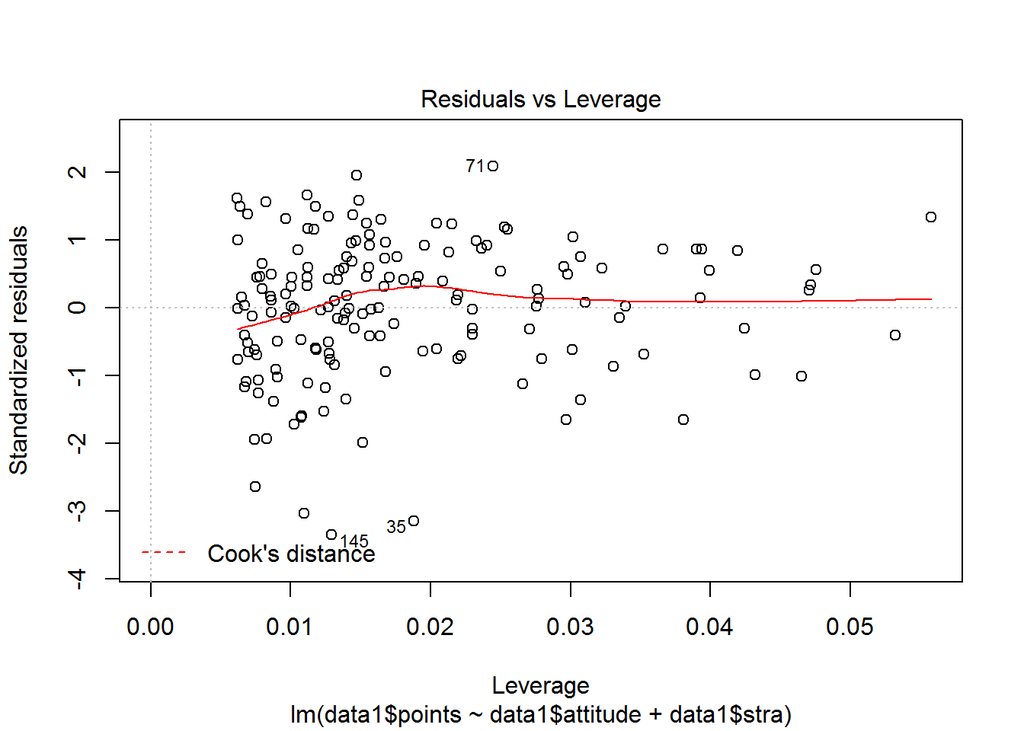

```r
plot(model2, which = c(5))
```

Here we can see how the standardized residuals are on the y-axis, and the leverage is on the x-axis. The residual axis shows how much the observations differs from the multiple regression line. The leverage on the x-axis explains how far the explanatory variables are from other observations.

### Summary of my learning

I have understood a little bit more on how to use RStudio and to syncronize with Github and so forth.

I have learned through the Datacamp excersizes new codes, that has been very usefull in this task. I have also learned to add pictures to a rmd file. I have also learned how to combine questions into new variables. But I was unable to exclude the variables that where 0 in the data wrangling excersize, so I had to use the ready made data.

I also have a slightly better understanding of the model where every variable is compared with each other. But I am quite familiar with the summary of the multiple regression model, so there was nothing very new.